Lake Name: Lake Devenoge

Lake acreage: 71.9

County: SULLIVAN

PWLID: 1401-0080

Waterbody Classification: B

Coordinates: 41.521,-74.839401

Is this waterbody a public water supply: No

Are there DOH desingated beaches on this waterbody: No

Open Water Indicators

2018 Sampling Results

Seasonal Change

06-10

06-24

07-14

08-18

09-03

09-22

09-30

Clarity (m)

3.75

2.25

4.20

3.20

3.55

3.00

2.90

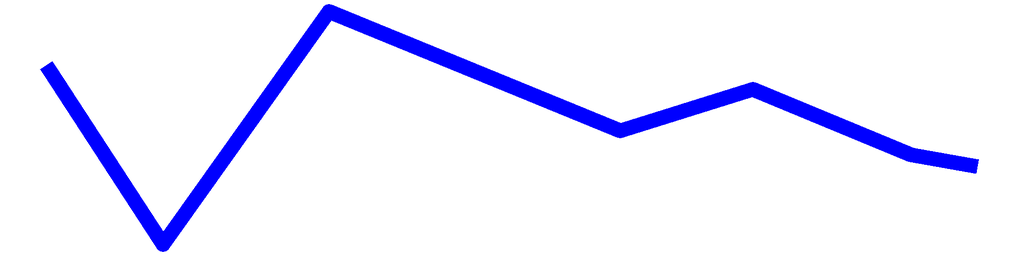

Surface TP (mg/L)

0.01

0.01

0.01

0.00

0.01

0.01

0.01

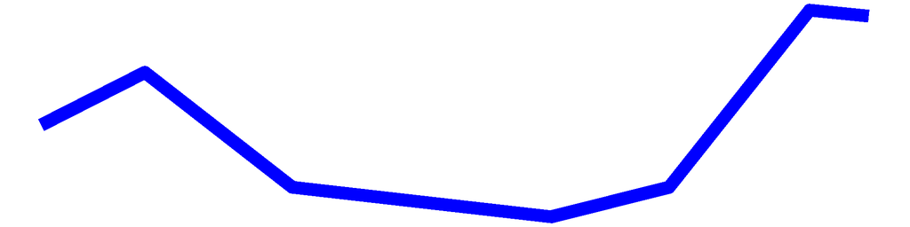

Surface TDP (mg/L)

0.01

0.00

0.01

0.00

0.00

0.01

0.00

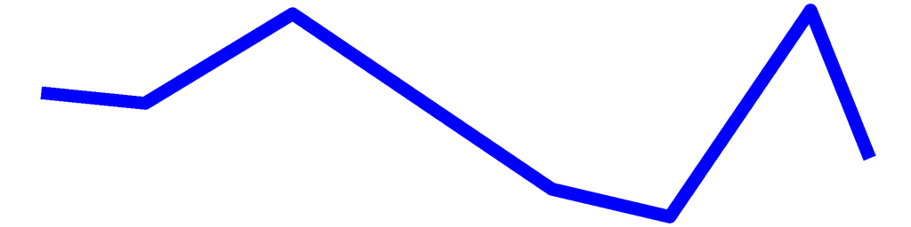

Deep TP (mg/L)

0.03

0.01

0.01

0.02

0.03

0.02

0.02

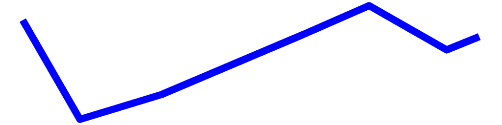

Deep TDP (mg/L)

0.01

0.01

0.01

0.00

0.01

0.00

0.01

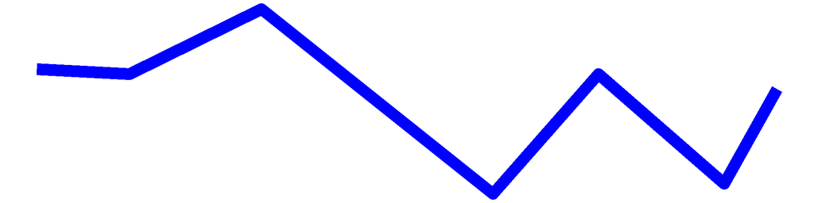

TN (mg/L)

0.34

0.42

0.38

0.31

0.31

0.24

0.37

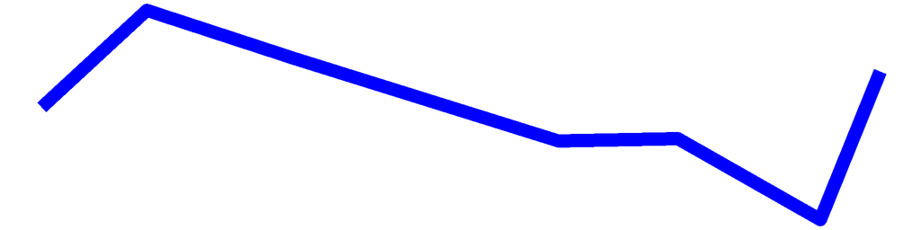

TDN (mg/L)

0.34

0.36

0.37

0.34

0.34

0.28

0.33

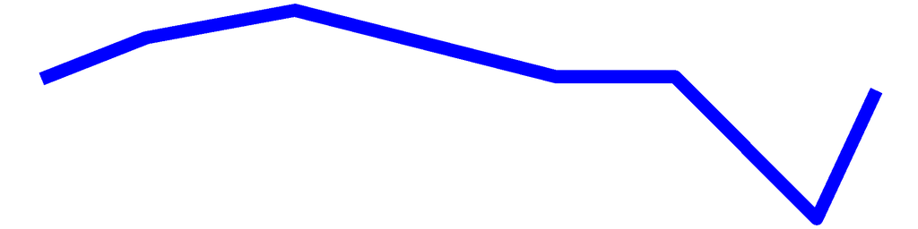

TN:TP

44.21

44.68

68.73

68.22

56.18

20.78

32.48

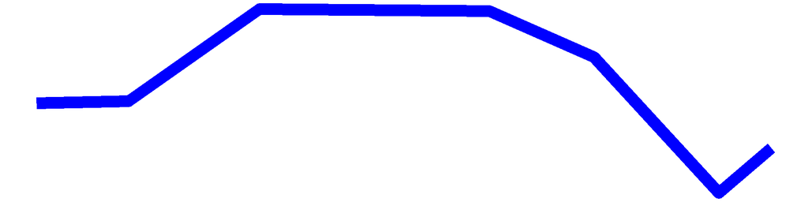

Surface NH3 (mg/L)

0.02

0.00

0.07

0.00

0.02

0.02

0.02

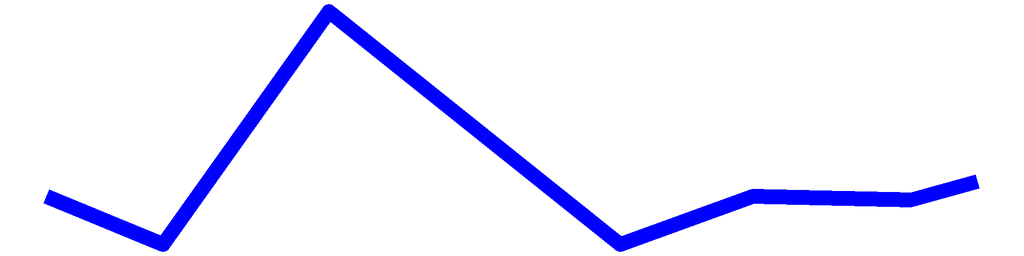

Deep NH3 (mg/L)

0.03

0.05

0.08

0.21

0.25

0.22

0.17

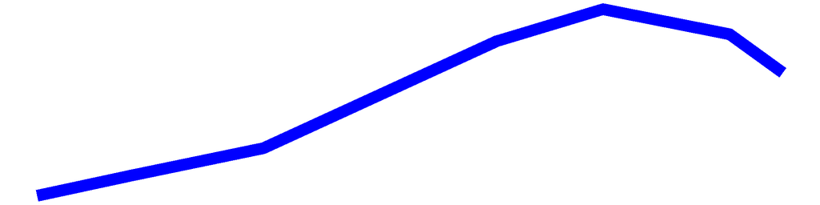

Chl.a (ug/L)

0.40

3.90

1.30

2.40

3.20

6.90

5.70

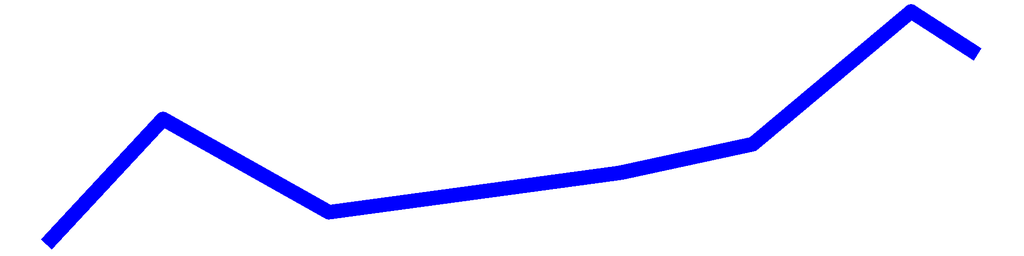

pH

6.73

6.94

7.20

7.30

7.02

7.33

7.61

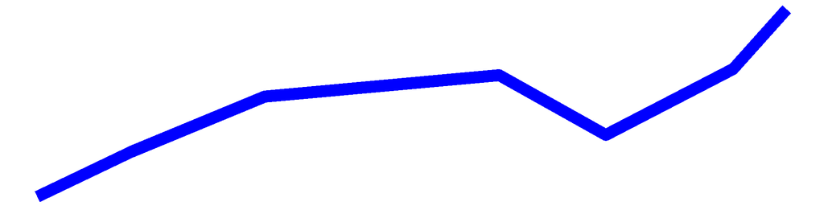

Cond (umho/cm)

160.90

149.10

194.80

146.60

143.10

159.70

159.80

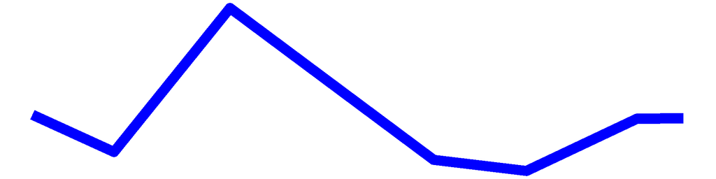

Surface Calcium (mg/L)

Bottom Calcium (mg/L)

Surface Chloride (mg/L)

42.90

39.80

Bottom Chloride (mg/L)

Upper Temp (degC)

21.00

23.00

27.00

34.00

24.00

20.50

18.00

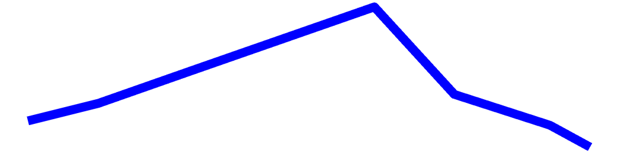

Deep Temp (degC)

10.00

15.00

16.00

15.00

13.50

11.00

12.00

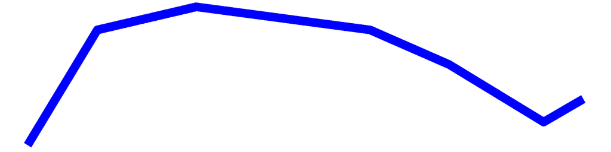

FP BG Chl.a (ug/L)

4.97

1.75

4.07

8.57

10.92

12.62

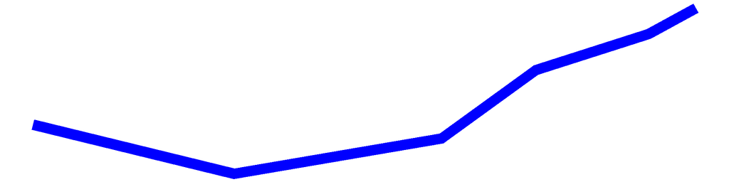

## Lake Devenoge – Sampling Season Results

### HABs Status

#### Open Water Algae

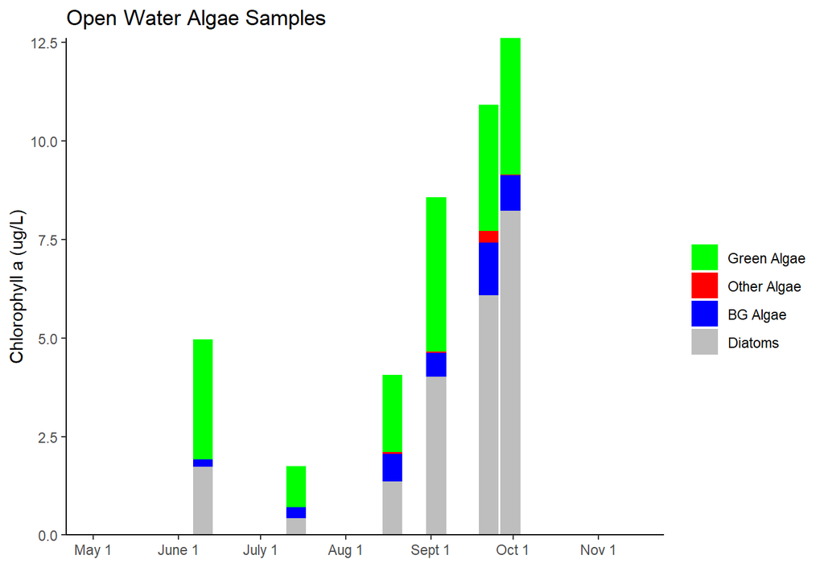

## Lake Devenoge Long-Term Trend Analysis

#### Clarity

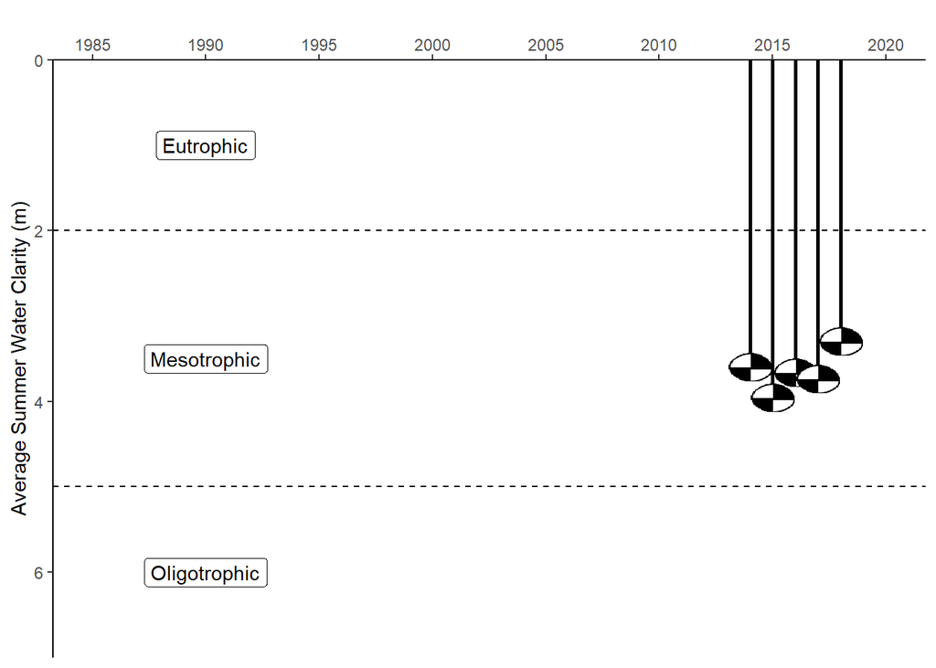

#### Chlorophyll *a*

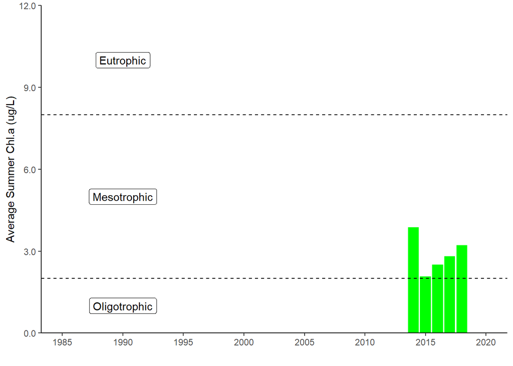

#### Surface and Deep Phosphorus

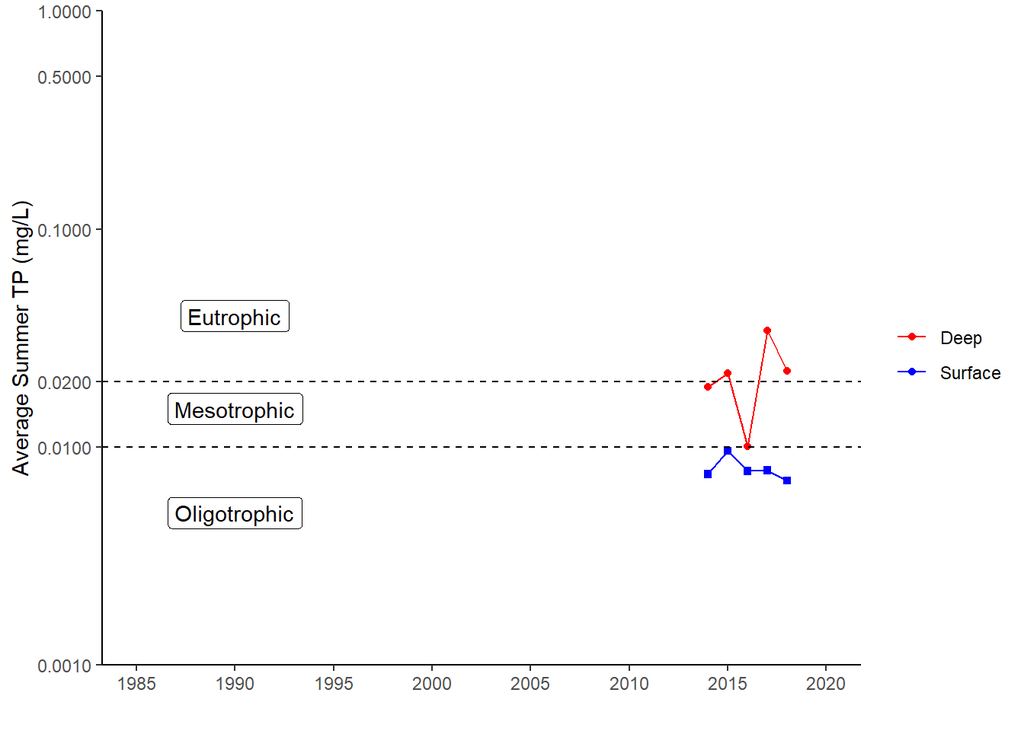

#### Nitrogen

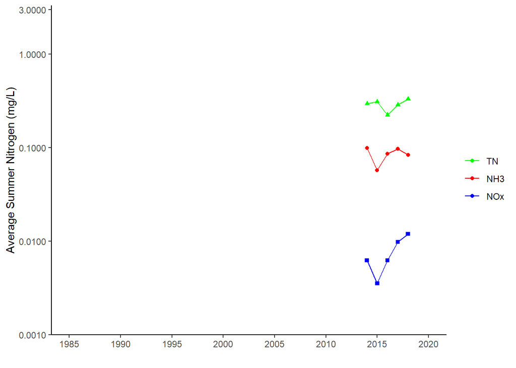

#### TN : TP

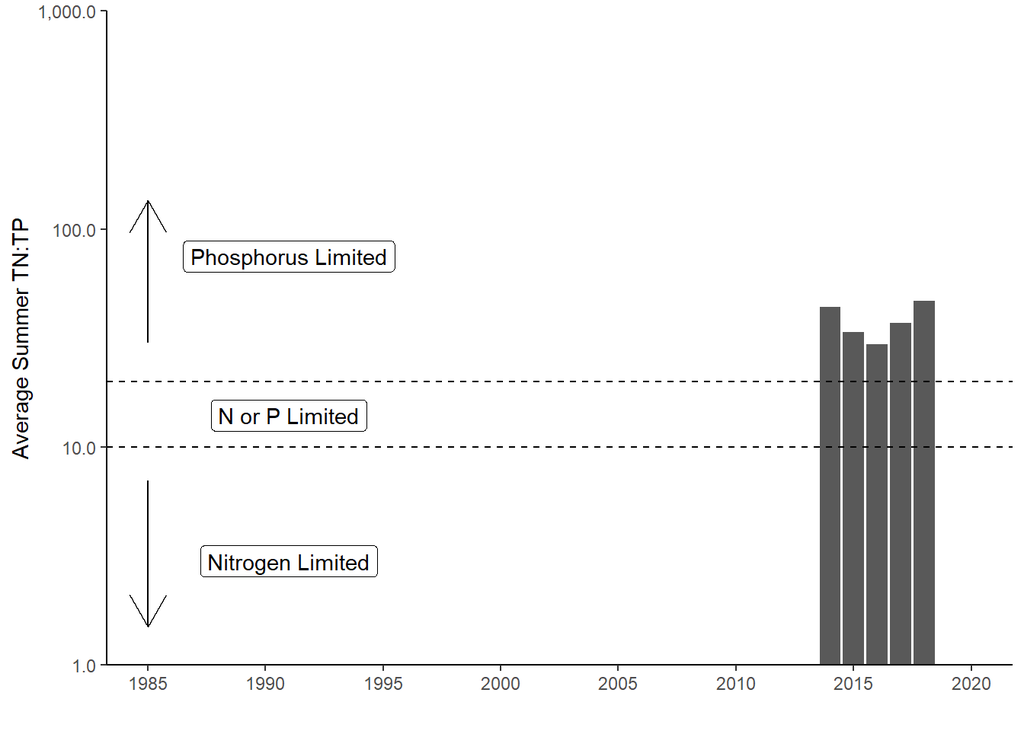

#### pH

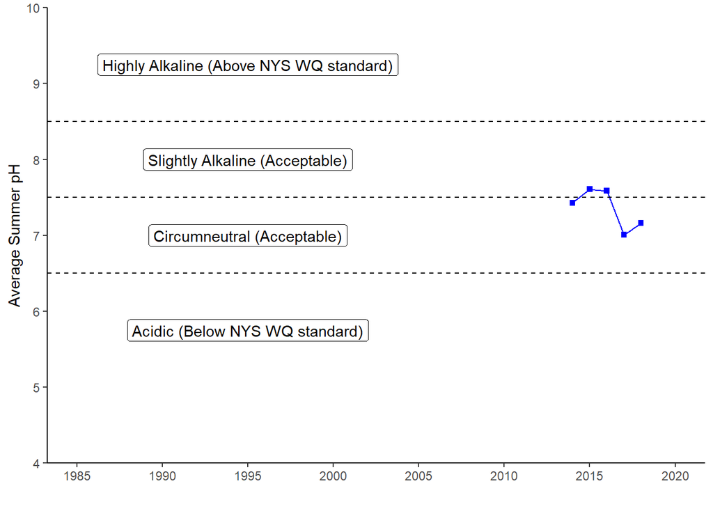

#### Specific Conductance

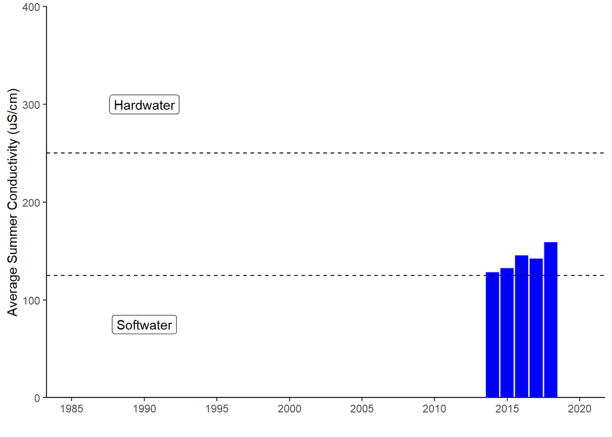

#### Calcium

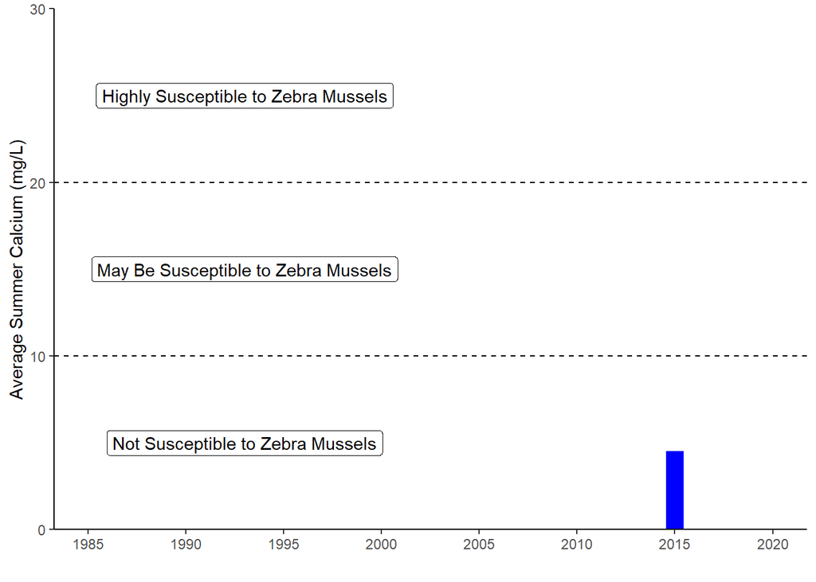

#### Chloride

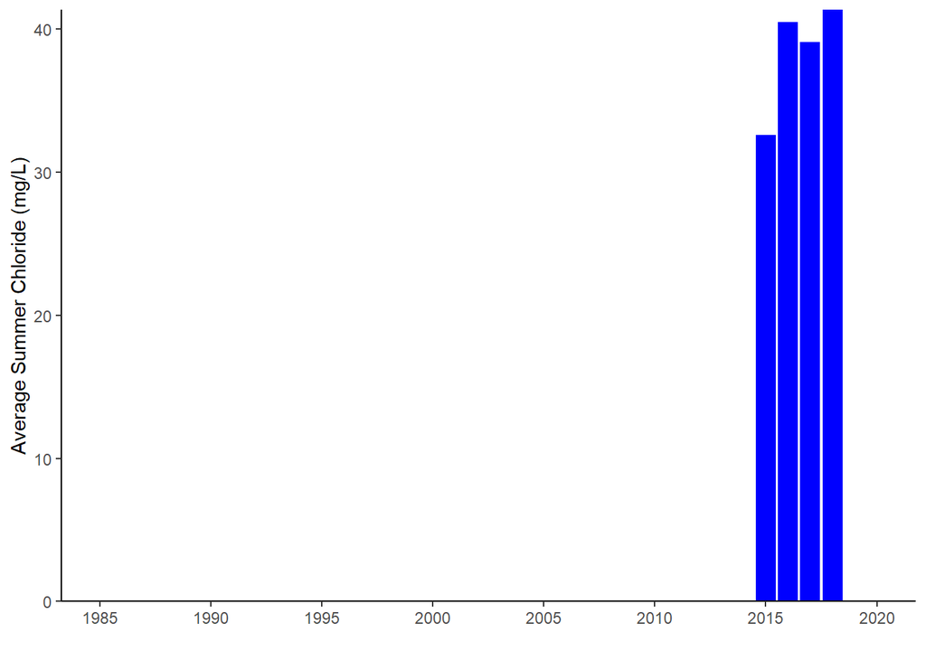

#### Color

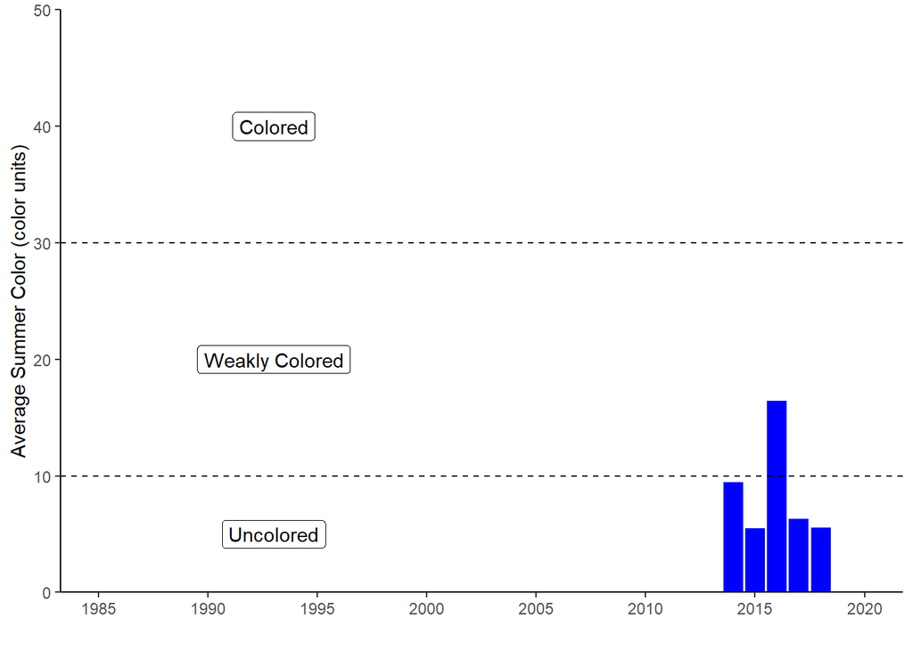

#### Surface and Deep Temperature

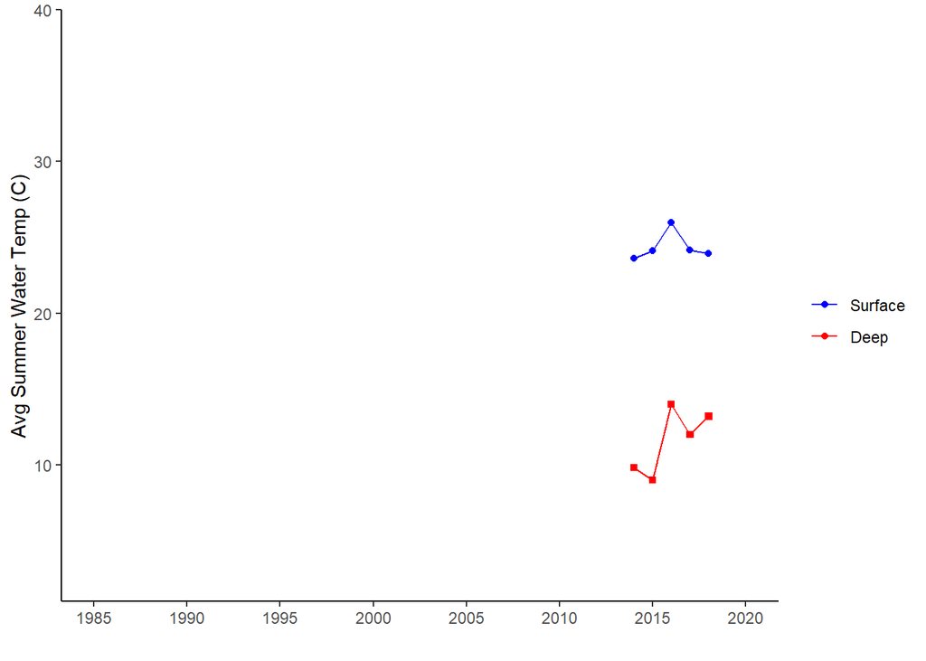

#### Lake Perception

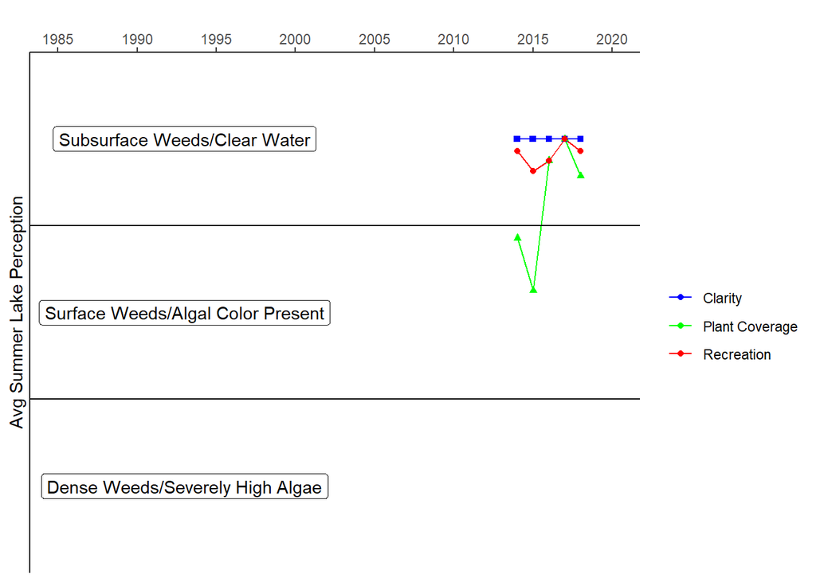

## Lake Devenoge - In-Season Analysis

#### In Season Water Clarity

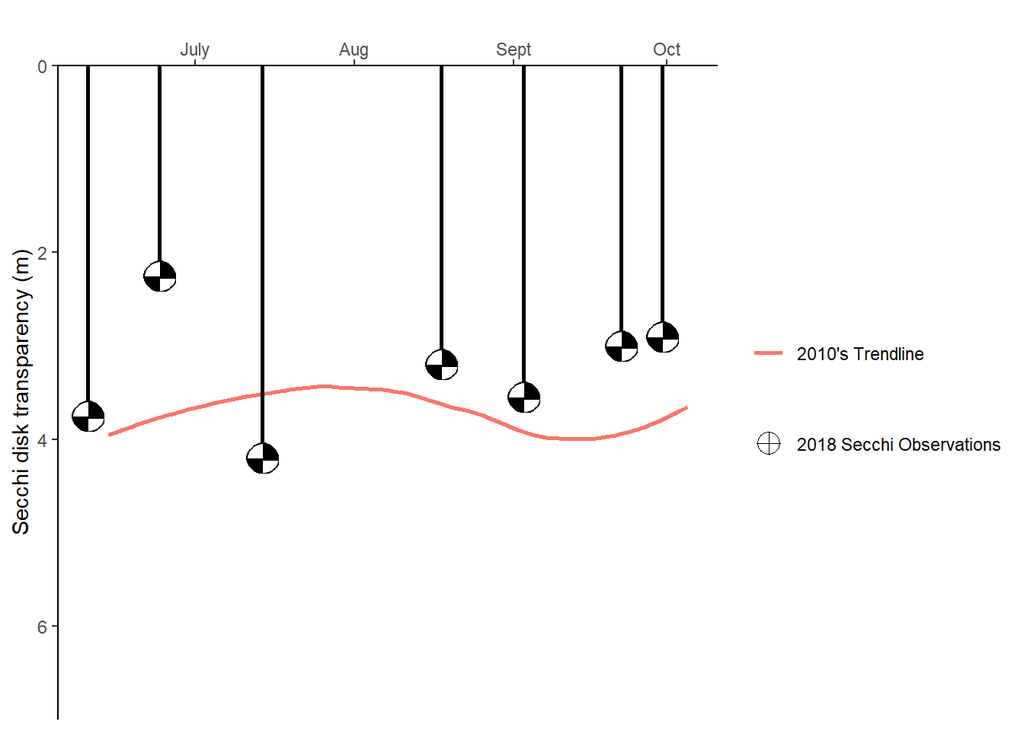

#### In Season Water Temperature

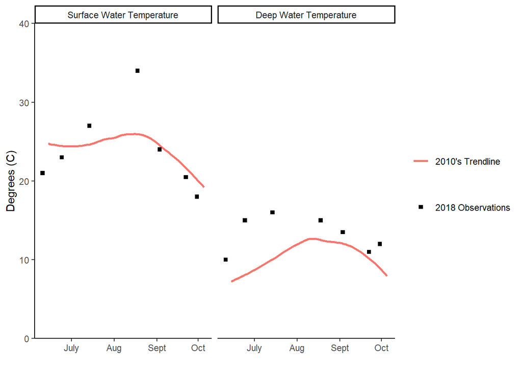